# Lab3

### Univariate Linear Regression on the California Housing Prices Dataset

## 1. Framing the Problem

The objective of this lab is to practice the implementation of linear regression models, utilizing a dataset focused on house price prediction. In addition, in order to understand and demonstrate the fundamental steps involved in machine learning workflows, specifically data handling with pandas, visualization with seaborn, model training and analysis and interpretation and insights.

## 2. Getting the Data

hyperlinking to the source [California Housing Prices Dataset](https://www.kaggle.com/datasets/camnugent/california-housing-prices)

```python
import pandas as pd
housing = pd.read_csv("data/housing.csv")
```

## 3. Exploratory Data Analysis (EDA)

### 1) Explore statistics

```python
housing.describe()
```

|  | longitude | latitude | housing_median_age | total_rooms | total_bedrooms | population | households | median_income | median_house_value |
| --- | --- | --- | --- | --- | --- | --- | --- | --- | --- |
| count | 20640.000000 | 20640.000000 | 20640.000000 | 20640.000000 | 20433.000000 | 20640.000000 | 20640.000000 | 20640.000000 | 20640.000000 |
| mean | -119.569704 | 35.631861 | 28.639486 | 2635.763081 | 537.870553 | 1425.476744 | 499.539680 | 3.870671 | 206855.816909 |
| std | 2.003532 | 2.135952 | 12.585558 | 2181.615252 | 421.385070 | 1132.462122 | 382.329753 | 1.899822 | 115395.615874 |
| min | -124.350000 | 32.540000 | 1.000000 | 2.000000 | 1.000000 | 3.000000 | 1.000000 | 0.499900 | 14999.000000 |
| 25% | -121.800000 | 33.930000 | 18.000000 | 1447.750000 | 296.000000 | 787.000000 | 280.000000 | 2.563400 | 119600.000000 |
| 50% | -118.490000 | 34.260000 | 29.000000 | 2127.000000 | 435.000000 | 1166.000000 | 409.000000 | 3.534800 | 179700.000000 |
| 75% | -118.010000 | 37.710000 | 37.000000 | 3148.000000 | 647.000000 | 1725.000000 | 605.000000 | 4.743250 | 264725.000000 |
| max | -114.310000 | 41.950000 | 52.000000 | 39320.000000 | 6445.000000 | 35682.000000 | 6082.000000 | 15.000100 | 500001.000000 |

### 2) Describe the 4 variables in the lab

Median Income

- its range is from 0.499900 to 15.000100. and mean is 3.870671, standard deviation is 1.899822, indicating a moderate spread around the mean.

Number of Households

- its range is from 1 to 6082 (wide range). and mean is 499.539680, standard deviation is 382.329753, indicating that it has significant variability.

Median House Value

- its range is from 14999 to 500001 (wide range). and mean is 206855.816909, standard deviation is 115395.615874, indicating that house values vary widely.

Other issues

- The maximum values for both population and the number of households are significantly higher than their respective means (large standard deviations). This indicates a wide dispersion of data points and suggests the presence of outliers.

### 3) Create three Seaborn Scatter plots

Plot of median house value versus median income

- Review: This plot shows a positive trend, implying that median house value tends to increase with median income. However, there are some strange point numbers in 500000.

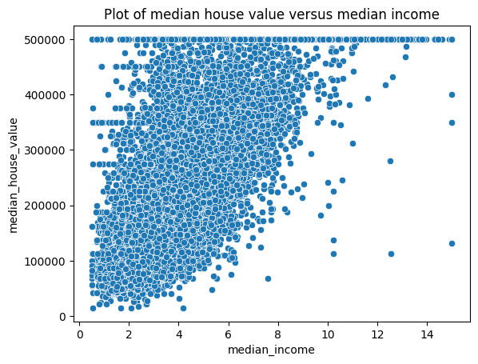

```python
import seaborn as sns
sns.scatterplot(x = "median_income", y = "median_house_value", data = housing).set_title("Plot of median house value versus median income")
```

Plot of median house value versus population

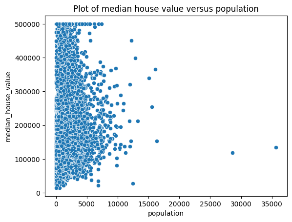

```python
sns.scatterplot(x = "population", y = "median_house_value", data = housing).set_title("Plot of median house value versus population")
```

Plot of median house value versus number of households

- Review: This plot also shows a slightly positive trend, although this trend is not that strong. And it shows a wider spread of data points than the former one.

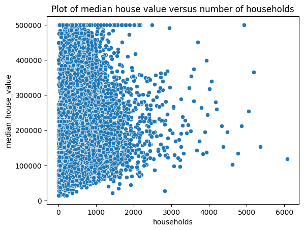

```python
sns.scatterplot(x = "households", y = "median_house_value", data = housing).set_title("Plot of median house value versus number of households")
```

## 4. Run three linear regressions

### 1) median house value vs. median income

```python
from sklearn import linear_model
from sklearn.metrics import mean_squared_error, mean_absolute_error
```

```python
model1 = linear_model.LinearRegression()
model1.fit(X=housing[["median_income"]], y = housing[["median_house_value"]])
```

```
LinearRegression()
```

### 2) median house value vs. population

```python
model2 = linear_model.LinearRegression()
model2.fit(X=housing[["population"]], y = housing[["median_house_value"]])
```

```
LinearRegression()
```

### 3) median house value vs. number of households

```python
model3 = linear_model.LinearRegression()
model3.fit(X=housing[["households"]], y = housing[["median_house_value"]])
```

```
LinearRegression()
```

## 5. summarize in a table

### 1) intercept and slope

```python
print("median house value vs. median income")
print(f" - Intercept: {model1.intercept_}")
print(f" - Slope: {model1.coef_}")

print("\nmedian house value vs. population")
print(f" - Intercept: {model2.intercept_}")
print(f" - Slope: {model2.coef_}")

print("\nmedian house value vs. number of households")
print(f" - Intercept: {model3.intercept_}")
print(f" - Slope: {model3.coef_}")
```

```
median house value vs. median income
 - Intercept: [45085.57670327]
 - Slope: [[41793.8492019]]

median house value vs. population
 - Intercept: [210436.26207627]
 - Slope: [[-2.51175277]]

median house value vs. number of households
 - Intercept: [196928.57716233]
 - Slope: [[19.87277516]]
```

### 2) Mean Squared Error - the loss

```python
print("median house value vs. median income")
print(f" - Mean squared error: {mean_squared_error(housing[['median_house_value']], model1.predict(housing[['median_income']]))}")

print("\nmedian house value vs. population")
print(f" - Mean squared error: {mean_squared_error(housing[['median_house_value']], model2.predict(housing[['population']]))}")

print("\nmedian house value vs. number of households")
print(f" - Mean squared error: {mean_squared_error(housing[['median_house_value']], model3.predict(housing[['households']]))}")
```

```
median house value vs. median income
 - Mean squared error: 7011311502.929527

median house value vs. population
 - Mean squared error: 13307412412.389355

median house value vs. number of households
 - Mean squared error: 13257776904.728533
```

### 3) Mean Absolute Error

```python
print("median house value vs. median income")
print(f"Mean absolute error: {mean_absolute_error(housing[['median_house_value']], model1.predict(housing[['median_income']]))}")

print("\nmedian house value vs. population")
print(f"Mean absolute error: {mean_absolute_error(housing[['median_house_value']], model2.predict(housing[['population']]))}")

print("\nmedian house value vs. number of households")
print(f"Mean absolute error: {mean_absolute_error(housing[['median_house_value']], model3.predict(housing[['households']]))}")
```

```
median house value vs. median income
Mean absolute error: 62625.9337911434

median house value vs. population
Mean absolute error: 91153.82009473183

median house value vs. number of households
Mean absolute error: 90802.74324318448
```

| independent variable | intercept | slope | mean squared error | mean absolute error |
| --- | --- | --- | --- | --- |
| median income | 45085.57670327 | 41793.8492019 | 7011311502.929527 | 62625.9337911434 |
| population | 210436.26207627 | -2.51175277 | 13307412412.389355 | 91153.82009473183 |
| number of households | 196928.57716233 | 19.87277516 | 13257776904.728533 | 90802.74324318448 |

## 6. Plot the resulting line on top of the scatter data

```python
import matplotlib.pyplot as plt
```

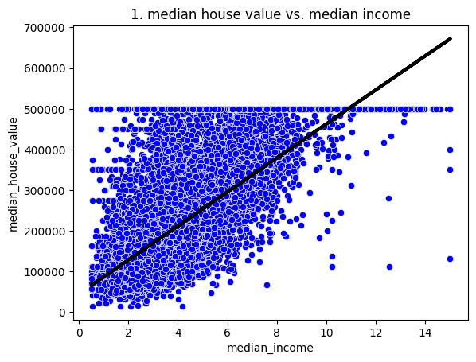

```python
sns.scatterplot(x="median_income", y="median_house_value", data=housing, color="Blue").set_title("1. median house value vs. median income")
plt.plot(housing[["median_income"]], model1.predict(housing[["median_income"]]), color="black", linewidth=3)
plt.show()
```

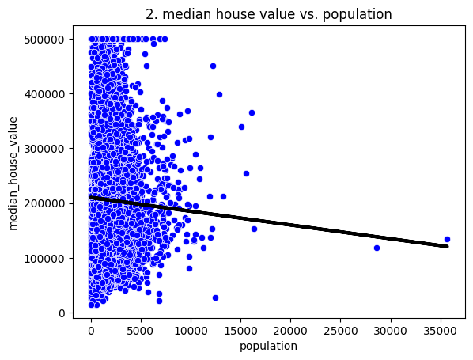

```python
sns.scatterplot(x="population", y="median_house_value", data=housing, color="blue").set_title("2. median house value vs. population")
plt.plot(housing[["population"]], model2.predict(housing[["population"]]), color="black", linewidth=3)
plt.show()
```

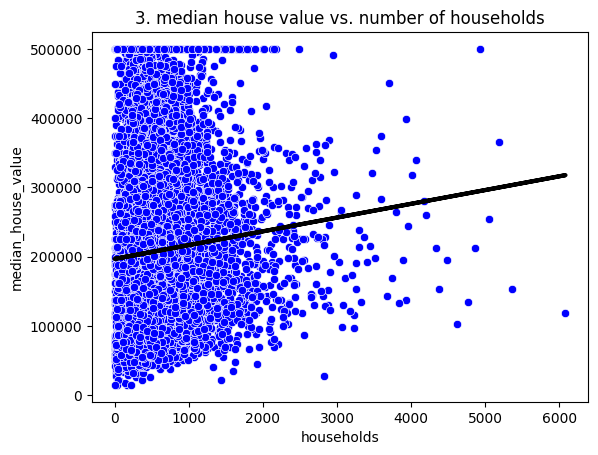

```python
sns.scatterplot(x="households", y="median_house_value", data=housing, color="blue").set_title("3. median house value vs. number of households")
plt.plot(housing[["households"]], model3.predict(housing[["households"]]), color="black", linewidth=3)
plt.show()
```

### 7. Conclusion

- goodness-of-fit: median income that model exhibits a lower mean squared error compared to those models using population and number of households. This lower MSE indicates that the median income model has a better fit, implying a more accurate prediction of median house values.
- insights: the scatter plot visualizations and linear line reinforce the numerical findings, with the median income plot demonstrating a stronger and more defined correlation with median house value than the other variables. This observation supports the hypothesis that median income may have a more direct and significant impact on housing prices than the sheer number of people or households in an area. Moreover, the presence of outliers in the data could be influencing the model's performance. A potential refinement of the model could involve outlier removal or the application of robust regression techniques that can mitigate the impact of these extreme values.